# Communicate-Data-Findings-Ford-GoBike-System

## Visualization 1

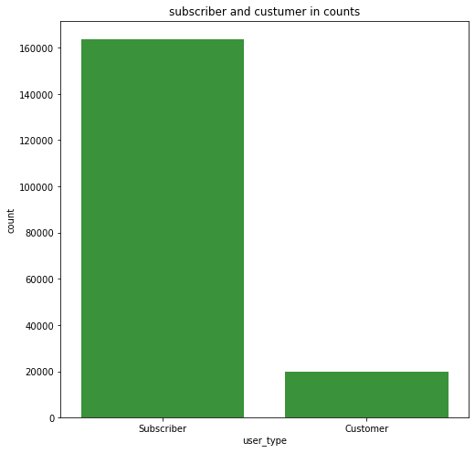

## Visualization 2

[figure not shown]

#### in the plot below irrespective of the gender only subscriber user number are way greater

- there may be less women population around or women who goes out as we can see that even female customers are also few

## Visualization 3

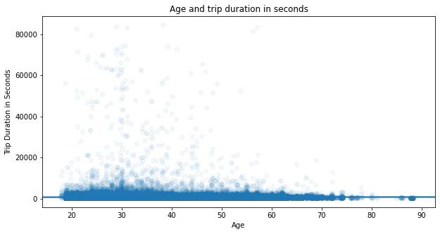

#### People between 20 and 40 years old tends to take more time in taking trips, this help them to concentrate on youth and make arrengements for their services in favour of youth inorder to attract youth.

## Visualization 4

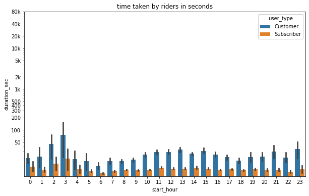

[output not shown]